# Breslow Seizure Data

This is an example form Kabacoff (2015) R in Action (Section 13.3, page 312.)

```r
#install.packages("robust")
library(robust)
```

```r
library(ggplot2)
library(patchwork)
```

To illustrate the fitting of a Poisson regression model, along with some issues that can come up in the analysis, we’ll use the Breslow seizure data (Breslow, 1993) provided in the `robust` package. Specifically, we’ll consider the impact of an antiepileptic drug treatment on the number of seizures occurring over an eight-week period following the initiation of therapy. Be sure to install the `robust` package before continuing.

Data were collected on the age and number of seizures reported by patients suffering from simple or complex partial seizures during an eight-week period before, and eightweek period after, randomization into a drug or placebo condition. **sumY** (the number of seizures in the eight-week period post-randomization) is the response variable. Treatment condition (**Trt**), age in years (**Age**), and number of seizures reported in the baseline eight-week period (**Base**) are the predictor variables. The baseline number of seizures and age are included because of their potential effect on the response variable. We are interested in whether or not evidence exists that the drug treatment decreases the number of seizures after accounting for these covariates.

First, let’s look at summary statistics for the dataset:

```r
data(breslow.dat, package="robust")
names(breslow.dat)
```

```
##  [1] "ID"    "Y1"    "Y2"    "Y3"    "Y4"    "Base"  "Age"   "Trt"   "Ysum"
## [10] "sumY"  "Age10" "Base4"
```

```r
summary(breslow.dat[c(6,7,8,10)])
```

```
##       Base             Age               Trt          sumY
##  Min.   :  6.00   Min.   :18.00   placebo  :28   Min.   :  0.00
##  1st Qu.: 12.00   1st Qu.:23.00   progabide:31   1st Qu.: 11.50
##  Median : 22.00   Median :28.00                  Median : 16.00
##  Mean   : 31.22   Mean   :28.34                  Mean   : 33.05
##  3rd Qu.: 41.00   3rd Qu.:32.00                  3rd Qu.: 36.00
##  Max.   :151.00   Max.   :42.00                  Max.   :302.00
```

Note that although there are 12 variables in the dataset, we’re limiting our attention to the four described earlier. Both the baseline and post-randomization number of seizures is highly skewed. Let’s look at the response variable in more detail.

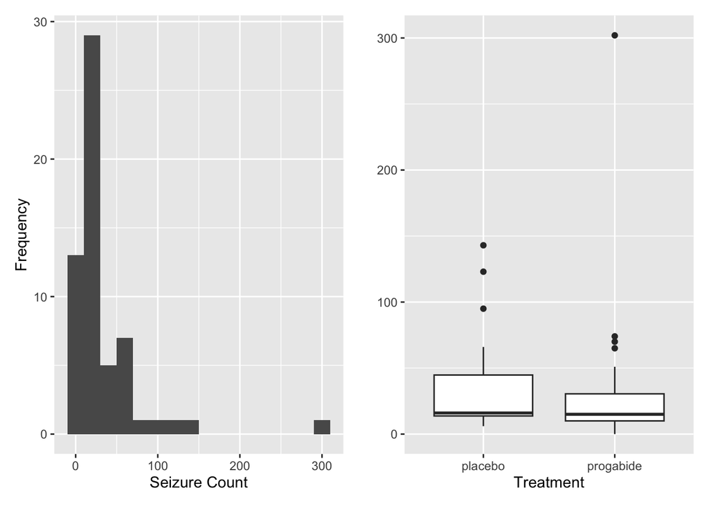

```r
p1 <- ggplot(data=breslow.dat, aes(sumY)) +
  geom_histogram(binwidth = 20) +
  xlab("Seizure Count") +
  ylab("Frequency")

p2 <- ggplot(data=breslow.dat, aes(Trt, sumY)) +
  geom_boxplot() +
  xlab("Treatment") +
  ylab("")

p1 + p2
```

You can clearly see the skewed nature of the dependent variable and the possible presence of outliers. At first glance, the number of seizures in the drug condition appears to be smaller and have a smaller variance. (You’d expect a smaller variance to accompany a smaller mean with Poisson distributed data.) Unlike standard OLS regression, this heterogeneity of variance isn’t a problem in Poisson regression.

The next step is to fit the Poisson regression:

```r
fit <- glm(sumY ~ Base + Age + Trt, data=breslow.dat, family=poisson())
summary(fit)
```

```
##
## Call:
## glm(formula = sumY ~ Base + Age + Trt, family = poisson(), data = breslow.dat)
##
## Coefficients:
##                Estimate Std. Error z value Pr(>|z|)
## (Intercept)   1.9488259  0.1356191  14.370  < 2e-16 ***
## Base          0.0226517  0.0005093  44.476  < 2e-16 ***
## Age           0.0227401  0.0040240   5.651 1.59e-08 ***
## Trtprogabide -0.1527009  0.0478051  -3.194   0.0014 **
## ---
## Signif. codes:  0 '***' 0.001 '**' 0.01 '*' 0.05 '.' 0.1 ' ' 1
##
## (Dispersion parameter for poisson family taken to be 1)
##
##     Null deviance: 2122.73  on 58  degrees of freedom
## Residual deviance:  559.44  on 55  degrees of freedom
## AIC: 850.71
##
## Number of Fisher Scoring iterations: 5
```

The output provides the deviances, regression parameters, standard errors, and tests that these parameters are 0. Note that each of the predictor variables is significant at the p<0.05 level.

The model coefficients are obtained using the coef() function, or by examining the Coefficients table in the `summary()` function output:

```r
coef(fit)
```

```
##  (Intercept)         Base          Age Trtprogabide
##   1.94882593   0.02265174   0.02274013  -0.15270095
```

It’s usually much easier to interpret the regression coefficients in the original scale of the dependent variable (number of seizures, rather than log number of seizures). To accomplish this, exponentiate the coefficients:

```r
 exp(coef(fit))
```

```
##  (Intercept)         Base          Age Trtprogabide
##    7.0204403    1.0229102    1.0230007    0.8583864
```

It’s important to remember that, like the exponeniated parameters in logistic regression, the exponeniated parameters in the Poisson model have a multiplicative rather than an additive effect on the response variable. Also, as with logistic regression, you must evaluate your model for overdispersion.

http://www.cs.uni.edu/~jacobson/4772/week11/R_in_Action.pdf